# Morgan Stanley Employee Sentiment Analysis

### Load Sentiment Lexicons

Three complementary lexicons are used to capture different dimensions of sentiment:

| Lexicon | What it measures |
| --- | --- |
| **NRC** | 8 discrete emotions + positive/negative |
| **Bing** | Binary positive vs. negative |
| **AFINN** | Numeric score from −5 (most negative) to +5 (most positive) |

```r
sentiments         <- get_sentiments("nrc")
sentiments_PN      <- get_sentiments("bing")
sentiments_numeric <- get_sentiments("afinn")
```

### Join Reviews with Sentiments

```r
review_sentiments         <- tidy_reviews %>% inner_join(sentiments,         relationship = "many-to-many")
review_sentiments_PN      <- tidy_reviews %>% inner_join(sentiments_PN,      relationship = "many-to-many")
review_sentiments_numeric <- tidy_reviews %>% inner_join(sentiments_numeric, relationship = "many-to-many")

# Categorise AFINN scores into three buckets
review_sentiments_numeric <- review_sentiments_numeric %>%
  mutate(
    sentiment_category = case_when(
      value >= -5 & value <= -2 ~ "Negative",
      value >= -1 & value <= 1  ~ "Neutral",
      value >= 2  & value <= 5  ~ "Positive"
    )
  )
```

### Overall Sentiment Distribution (NRC)

```r
sentiment_n <- review_sentiments %>%
  filter(Current_employee == FALSE) %>%
  count(sentiment, sort = TRUE) %>%
  ungroup()

sentiment_n
```

| sentiment | n |
| --- | --- |
| positive | 14946 |
| trust | 9264 |
| anticipation | 5737 |
| joy | 4057 |
| negative | 3578 |
| fear | 1674 |
| sadness | 1574 |
| anger | 1471 |
| surprise | 1443 |
| disgust | 859 |

**Key finding:** Across both platforms, the dominant emotion is *positive*, followed by *trust* and *anticipation* - consistent with Morgan Stanley’s strong employer brand. Negative emotions (fear, anger, disgust) are present but in the minority.

The tables below show the full NRC emotion counts for each platform (former employees only):

**Indeed**

| Sentiment | Count |
| --- | --- |
| positive | 9,701 |
| trust | 6,066 |
| anticipation | 3,647 |
| joy | 2,535 |
| negative | 2,078 |
| fear | 995 |
| surprise | 910 |
| sadness | 884 |
| anger | 799 |
| disgust | 445 |

**Glassdoor**

| Sentiment | Count |
| --- | --- |
| positive | 5,245 |
| trust | 3,198 |
| anticipation | 2,090 |
| joy | 1,522 |
| negative | 1,500 |
| sadness | 690 |
| fear | 679 |
| anger | 672 |
| surprise | 533 |
| disgust | 414 |

Notably, the ordering of negative emotions differs between platforms: on Indeed, *fear* edges out *sadness*, while on Glassdoor the two are effectively tied - a subtle but consistent signal that Indeed reviewers frame dissatisfaction through job-security concerns, while Glassdoor reviewers lean more toward disappointment.

### Top Words per NRC Sentiment

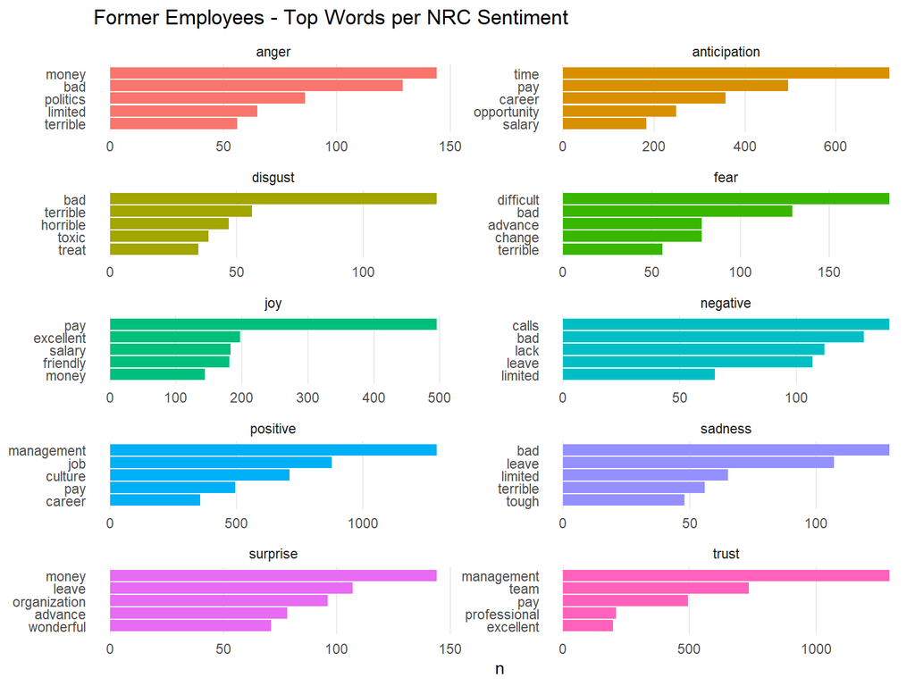

```r
top_sentiments_former <- review_sentiments %>%
  filter(Current_employee == FALSE) %>%
  group_by(sentiment) %>%
  count(sentiment, word, sort = TRUE) %>%
  slice_max(n, n = 5, with_ties = FALSE) %>%
  ungroup() %>%
  mutate(.r = -row_number())

top_sentiments_former %>%
  ggplot(aes(.r, n, fill = sentiment)) +
  scale_x_continuous(
    breaks = top_sentiments_former$.r,
    labels = top_sentiments_former$word
  ) +
  geom_col(show.legend = FALSE) +
  facet_wrap(~ sentiment, nrow = 5, scales = "free") +
  labs(title = "Former Employees - Top Words per NRC Sentiment") +
  coord_flip() +
  theme_minimal() +
  theme(
    panel.grid.major   = element_blank(),
    panel.grid.minor   = element_blank(),
    panel.grid.major.x = element_line(),
    axis.title.y       = element_blank()
  )
```

```r
#ggsave("Top words per sentiment.tiff", height = 10, width = 6, dpi = 700)
```

### Positive vs. Negative (Bing)

```r
sentiment_n_PN <- review_sentiments_PN %>%
  filter(Current_employee == FALSE) %>%
  count(sentiment, sort = TRUE) %>%
  ungroup()

sentiment_n_PN
```

| sentiment | n |
| --- | --- |
| positive | 8117 |
| negative | 4169 |

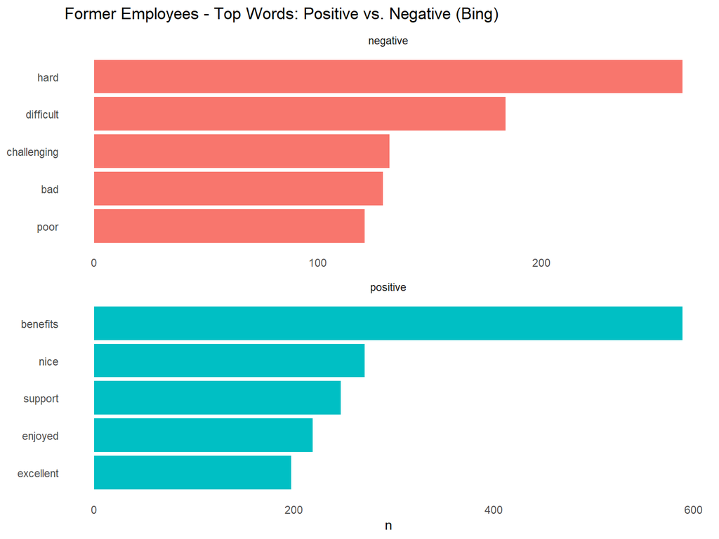

```r
top_sentiments_former_PN <- review_sentiments_PN %>%
  filter(Current_employee == FALSE) %>%
  group_by(sentiment) %>%
  count(sentiment, word, sort = TRUE) %>%
  slice_max(n, n = 5, with_ties = FALSE) %>%
  ungroup() %>%
  mutate(.r = -row_number())

top_sentiments_former_PN %>%
  ggplot(aes(.r, n, fill = sentiment)) +
  scale_x_continuous(
    breaks = top_sentiments_former_PN$.r,
    labels = top_sentiments_former_PN$word
  ) +
  geom_col(show.legend = FALSE) +
  facet_wrap(~ sentiment, nrow = 5, scales = "free") +
  labs(title = "Former Employees - Top Words: Positive vs. Negative (Bing)") +
  coord_flip() +
  theme_minimal() +
  theme(
    panel.grid.major = element_blank(),
    panel.grid.minor = element_blank(),
    axis.title.y     = element_blank()
  )
```

```r
#ggsave("Negative vs positive top words per sentiment.tiff", height = 10, width = 6, dpi = 700)
```

### Negative / Neutral / Positive (AFINN)

```r
sentiment_n_numeric <- review_sentiments_numeric %>%
  filter(Current_employee == FALSE) %>%
  count(sentiment_category, sort = TRUE) %>%
  ungroup()

sentiment_n_numeric
```

| sentiment_category | n |
| --- | --- |
| Positive | 6375 |
| Neutral | 3068 |
| Negative | 1748 |

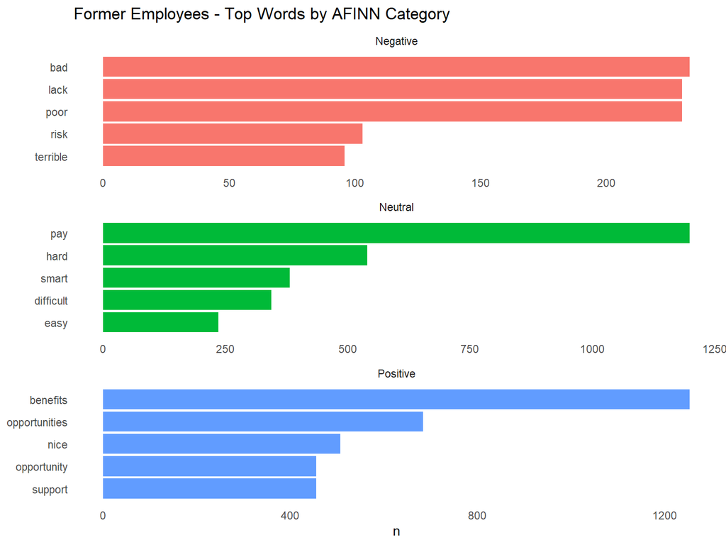

```r
top_words_afinn <- review_sentiments_numeric %>%
  filter(!is.na(sentiment_category)) %>%
  group_by(sentiment_category) %>%
  count(sentiment_category, word, sort = TRUE) %>%
  slice_max(n, n = 5, with_ties = FALSE) %>%
  ungroup() %>%
  mutate(.r = -row_number())

top_words_afinn %>%
  ggplot(aes(.r, n, fill = sentiment_category)) +
  scale_x_continuous(
    breaks = top_words_afinn$.r,
    labels = top_words_afinn$word
  ) +
  geom_col(show.legend = FALSE) +
  facet_wrap(~ sentiment_category, nrow = 3, scales = "free") +
  labs(title = "Former Employees - Top Words by AFINN Category") +
  coord_flip() +
  theme_minimal() +
  theme(
    panel.grid.major = element_blank(),
    panel.grid.minor = element_blank(),
    axis.title.y     = element_blank()
  )
```

```r
#ggsave("Pos-neut-neg top words per sentiment.tiff", height = 10, width = 6, dpi = 700)
```

**Key finding:** AFINN’s three-way split adds resolution that Bing’s binary categorisation misses. On **Indeed**, **4,076** tokens score as positive, **1,726** as neutral, and only **912** as negative - a healthy positive skew. **Glassdoor** shows the same ordering but compressed: **2,299 positive**, **1,342 neutral**, **836 negative**. The lower positive-to-negative ratio on Glassdoor (2.7×) compared with Indeed (4.5×) suggests that Glassdoor reviewers, despite their broadly positive framing, surface more granular criticism - in line with the platform’s structured pros/cons format.

### Sentiment Trends Over Time

#### NRC Emotions by Time Period

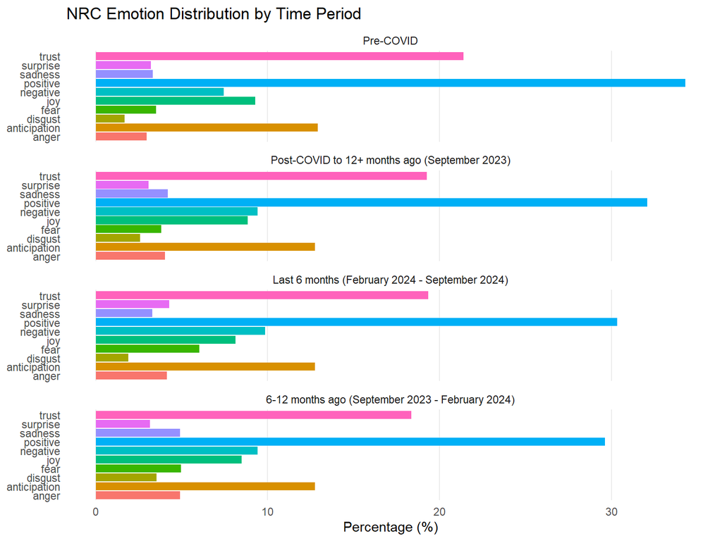

```r
sentiment_n_by_time <- review_sentiments %>%
  filter(Current_employee == FALSE) %>%
  count(sentiment, time_segment, sort = TRUE) %>%
  ungroup()

sentiment_n_by_time_by_percent <- sentiment_n_by_time %>%
  group_by(time_segment) %>%
  mutate(percent = n / sum(n) * 100) %>%
  ungroup()

sentiment_n_by_time_by_percent %>%
  mutate(time_segment = fct_relevel(
    time_segment, "Pre-COVID", "Post-COVID to 12+ months ago (September 2023)", "6-12 months ago (September 2023 - February 2024", "Last 6 months (February 2024 - September 2024"
  )) %>%
  ggplot(aes(x = sentiment, y = percent, fill = sentiment)) +
  geom_col() +
  facet_wrap(~ time_segment, ncol = 1) +
  labs(
    title = "NRC Emotion Distribution by Time Period",
    y = "Percentage (%)", x = NULL
  ) +
  coord_flip() +
  theme_minimal() +
  theme(
    legend.position    = "none",
    panel.grid.major   = element_blank(),
    panel.grid.minor   = element_blank(),
    panel.grid.major.x = element_line()
  )
```

```r
#ggsave("Top words per sentiment by time.tiff", height = 14, width = 8, dpi = 700)
```

#### Bing Positive vs. Negative by Time Period

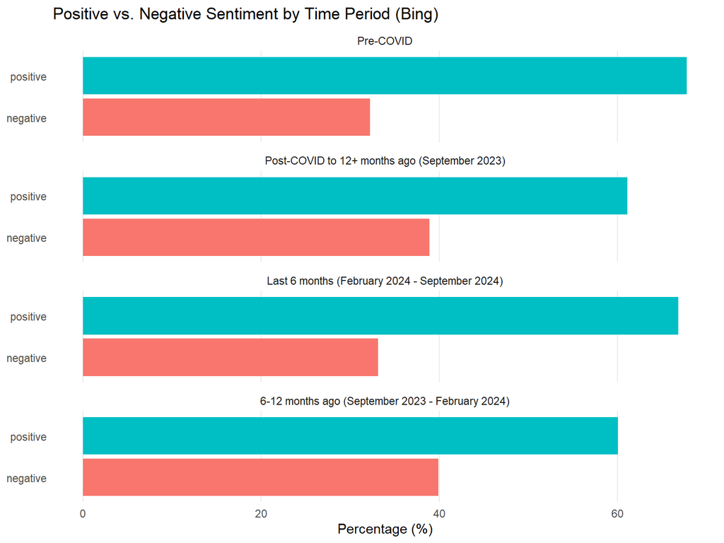

```r
sentiment_n_PN_by_time <- review_sentiments_PN %>%
  filter(Current_employee == FALSE) %>%
  count(sentiment, time_segment, sort = TRUE) %>%
  ungroup()

sentiment_n_PN_by_time_by_percent <- sentiment_n_PN_by_time %>%
  group_by(time_segment) %>%
  mutate(percent = n / sum(n) * 100) %>%
  ungroup()

sentiment_n_PN_by_time_by_percent %>%
  mutate(time_segment = fct_relevel(
    time_segment, "Pre-COVID", "Post-COVID to 12+ months ago (September 2023)", "6-12 months ago (September 2023 - February 2024", "Last 6 months (February 2024 - September 2024"
  )) %>%
  ggplot(aes(x = sentiment, y = percent, fill = sentiment)) +
  geom_col() +
  facet_wrap(~ time_segment, nrow = 4) +
  labs(
    title = "Positive vs. Negative Sentiment by Time Period (Bing)",
    y = "Percentage (%)", x = NULL
  ) +
  coord_flip() +
  theme_minimal() +
  theme(
    legend.position    = "none",
    panel.grid.major   = element_blank(),
    panel.grid.minor   = element_blank(),
    panel.grid.major.x = element_line()
  )
```

```r
#ggsave("Top words per sentiment pos vs neg by time.tiff", height = 10, width = 6, dpi = 700)
```

#### AFINN Category Shares by Time Period

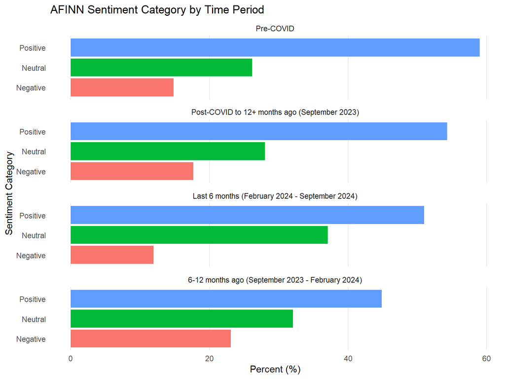

```r
sentiment_n_numeric_by_time <- review_sentiments_numeric %>%
  filter(Current_employee == FALSE) %>%
  count(sentiment_category, time_segment, sort = TRUE) %>%
  ungroup()

sentiment_n_numeric_by_time_by_percent <- sentiment_n_numeric_by_time %>%
  group_by(time_segment) %>%
  mutate(percent = n / sum(n) * 100) %>%
  ungroup()

sentiment_n_numeric_by_time_by_percent %>%
  mutate(time_segment = fct_relevel(
    time_segment, "Pre-COVID", "Post-COVID to 12+ months ago (September 2023)", "6-12 months ago (September 2023 - February 2024", "Last 6 months (February 2024 - September 2024"
  )) %>%
  ggplot(aes(x = sentiment_category, y = percent, fill = sentiment_category)) +
  geom_col() +
  facet_wrap(~ time_segment, ncol = 1) +
  labs(
    title = "AFINN Sentiment Category by Time Period",
    x = "Sentiment Category", y = "Percent (%)"
  ) +
  coord_flip() +
  theme_minimal() +
  theme(
    legend.position    = "none",
    panel.grid.major   = element_blank(),
    panel.grid.minor   = element_blank(),
    panel.grid.major.x = element_line()
  )
```

```r
#ggsave("Top words per sentiment pos neutr neg by time.tiff", height = 10, width = 6, dpi = 700)
```

#### Continuous Sentiment Trend (AFINN Score over Date)

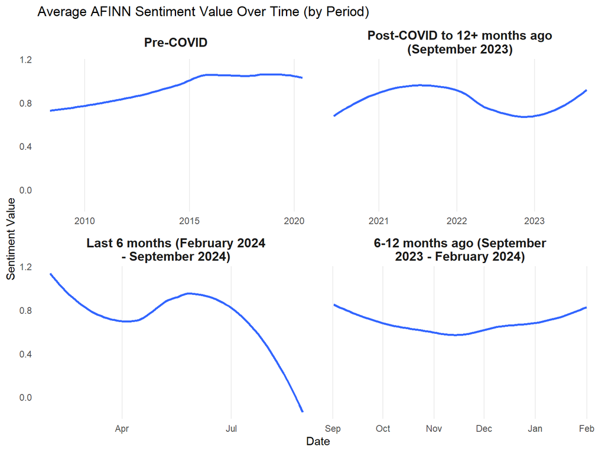

```r
review_sentiments_numeric %>%
  mutate(time_segment = fct_relevel(
    time_segment, "Pre-COVID", "Post-COVID to 12+ months ago (September 2023)", "6-12 months ago (September 2023 - February 2024", "Last 6 months (February 2024 - September 2024"
  )) %>%
  ggplot(aes(x = Date, y = value)) +
  geom_smooth(method = "loess", se = FALSE) +
  facet_wrap(~ time_segment, scales = "free_x", ncol = 2, labeller = label_wrap_gen(width = 30)) +
  labs(
    title = "Average AFINN Sentiment Value Over Time (by Period)",
    x = "Date", y = "Sentiment Value"
  ) +
  theme_minimal() +
  theme(
    panel.grid.major   = element_blank(),
    panel.grid.minor   = element_blank(),
    panel.grid.major.x = element_line(),
    strip.text         = element_text(size = 12, face = "bold")
  )
```

```r
#ggsave("Average positivity of sentiment over time.tiff", height = 8, width = 10, dpi = 700)
```

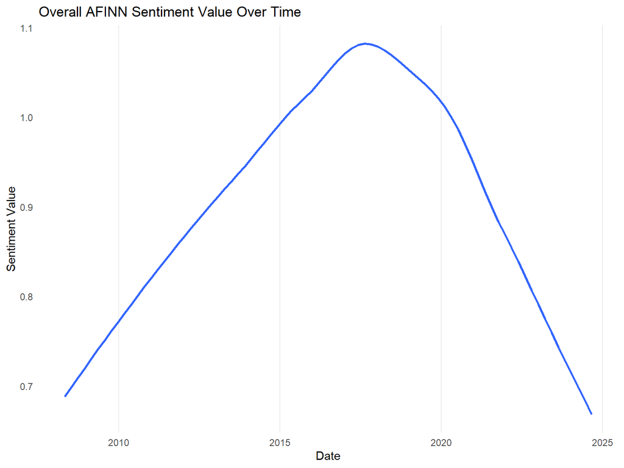

```r
review_sentiments_numeric %>%
  ggplot(aes(x = Date, y = value)) +
  geom_smooth(method = "loess", se = FALSE) +
  labs(
    title = "Overall AFINN Sentiment Value Over Time",
    x = "Date", y = "Sentiment Value"
  ) +
  theme_minimal() +
  theme(
    panel.grid.major   = element_blank(),
    panel.grid.minor   = element_blank(),
    panel.grid.major.x = element_line()
  )
```

```r
#ggsave("Average positivity of sentiment over time without segregation.tiff", height = 8, width = 10, dpi = 700)
```

- On **Indeed**, the LOESS trend line starts declining around 2015–2016 and recently crosses into **negative territory** in the most recent window - the starkest signal in the dataset. Emotions of *fear* and *anger* have grown relative to *joy* across successive periods.
- On **Glassdoor**, the trajectory is similar though slightly less severe: sentiment has fallen consistently since 2020, but the **last 6 months (February–September 2024)** show a partial recovery toward *neutral* rather than tipping negative - a tentative sign of stabilisation.
- The **combined dataset** reinforces both signals: AFINN scores peaked around **2018** before entering a sustained post-COVID decline, with the merged LOESS curve sitting below pre-COVID baselines throughout the most recent period.

## Key Findings

### Indeed Reviews

- The dominant NRC emotion is **positive** (**9,701** tokens), followed by *trust* (6,066), *anticipation* (3,647), and *joy* (2,535). Negative emotions are in the minority, led by *fear* (995) and *surprise* (910), with *disgust* the least represented (445).
- The positive framing holds across all three lexicons: Bing returns **5,200 positive** vs. **2,345 negative** words; AFINN shows **4,076 positive**, **1,726 neutral**, and only **912 negative** tokens - a positive-to-negative ratio of roughly 4.5:1.
- Temporally, the average sentiment has **declined from the pre-COVID period to the present**, with *fear* and *anger* growing and *joy* receding across successive periods. The AFINN trend line, which peaked around 2015–2016, crosses into **negative territory** in the most recent 6-month window - the most striking single finding in the dataset.

### Glassdoor Reviews

- Results mirror Indeed: *positive* leads (**5,245**), followed by *trust* (**3,198**) and *anticipation* (**2,090**). Unlike Indeed, *sadness* ranks above *fear* on Glassdoor - reflecting the platform’s structured pros/cons format, which may elicit more reflective, disappointment-oriented language.
- Bing: **2,917 positive** vs. **1,824 negative** (ratio ≈ 1.6:1 - lower than Indeed’s 2.2:1). AFINN: **2,299 positive**, **1,342 neutral**, **836 negative**.
- The downward trend is visible here too, but the **last 6-month window shows a partial recovery toward neutral** rather than negative - a tentative sign of stabilisation not present in the Indeed data.

### Combined Picture

When both datasets are merged, the long-run AFINN trend confirms a **peak around 2018** followed by a sustained decline through the post-COVID period. The merged LOESS curve sits below pre-COVID baselines throughout the most recent window, suggesting structural - rather than event-driven - shifts in employee experience at the firm.